# Comparing, evaluating and combining statistical species distribution models and CLIMEX to forecast the distributions of emerging crop pests - Early - 2022 - Pest Management Science - Wiley Online Libr

Czechs- Biological Institution

[Pest Management Science](https://onlinelibrary.wiley.com/journal/15264998)

[Volume 78, Issue 2](https://onlinelibrary.wiley.com/toc/15264998/2022/78/2) p. 671-683

[figure not shown]

Research Article

Open Access

# Comparing, evaluating and combining statistical species distribution models and CLIMEX to forecast the distributions of emerging crop pests

[Regan Early](https://onlinelibrary.wiley.com/action/doSearch?ContribAuthorRaw=Early%2C+Regan),

[Ivan Rwomushana](https://onlinelibrary.wiley.com/action/doSearch?ContribAuthorRaw=Rwomushana%2C+Ivan),

[Gilson Chipabika](https://onlinelibrary.wiley.com/action/doSearch?ContribAuthorRaw=Chipabika%2C+Gilson),

[Roger Day](https://onlinelibrary.wiley.com/action/doSearch?ContribAuthorRaw=Day%2C+Roger),

First published: 13 October 2021

https://doi.org/10.1002/ps.6677

## Abstract

### BACKGROUND

Forecasting the spread of emerging pests is widely requested by pest management agencies in order to prioritise and target efforts. Two widely used approaches are statistical Species Distribution Models (SDMs) and CLIMEX, which uses ecophysiological parameters. Each have strengths and weaknesses. SDMs can incorporate almost any environmental condition and their accuracy can be formally evaluated to inform managers. However, accuracy is affected by data availability and can be limited for emerging pests, and SDMs usually predict year-round distributions, not seasonal outbreaks. CLIMEX can formally incorporate expert ecophysiological knowledge and predicts seasonal outbreaks. However, the methods for formal evaluation are limited and rarely applied. We argue that both approaches can be informative and complementary, but we need tools to integrate and evaluate their accuracy. Here we develop such an approach, and test it by forecasting the potential global range of the tomato pest *Tuta absoluta*.

### RESULTS

The accuracy of previously developed CLIMEX and new statistical SDMs were comparable on average, but the best statistical SDM techniques and environmental data substantially outperformed CLIMEX. The ensembled approach changes expectations of *T. absoluta*'s spread. The pest's environmental tolerances and potential range in Africa, the Arabian Peninsula, Central Asia and Australia will be larger than previous estimates.

### CONCLUSION

We recommend that CLIMEX be considered one of a suite of SDM techniques and thus evaluated formally. CLIMEX and statistical SDMs should be compared and ensembled if possible. We provide code that can be used to do so when employing the biomod suite of SDM techniques. © 2021 The Authors. *Pest Management Science* published by John Wiley & Sons Ltd on behalf of Society of Chemical Industry.

## 1 INTRODUCTION

With increasing globalisation of trade and transport networks, the number of invasive pest species introduced around the world is continually increasing.<sup>1, 2</sup> Pest managers at local, national and global scales often want to know how far an emerging, introduced pest species will ultimately spread. This information can help prioritise species for funding and management, and alert growers to the potential arrival of a pest in time to mitigate the consequences.<sup>3</sup> A pest species’ potential range can be estimated on the basis of the environmental conditions it can tolerate.<sup>4</sup> Perhaps the most common approaches to predict pest ranges are statistical Species Distribution Models (SDMs) and CLIMEX. Although the two approaches share similar principles, often they are seen as fundamentally different.<sup>5</sup> Thus, there has been little comparison of their results, and no formal means for comparing or integrating predictions.

Statistical SDMs calculate the statistical relationship between the locations where a species is recorded and the environmental conditions at those locations.<sup>6</sup> This approach has benefits and drawbacks. First, the accuracy of the relationship and the projection of the pest's potential geographical range, is usually formally evaluated using data on the species’ distribution separate to data used to calculate models.<sup>7</sup> This could include the species’ distribution in a separate geographical region or time period,<sup>8, 9</sup> although commonly a ‘semi-independent’ subset of the data within the same region or time is used.<sup>6</sup> This provides a standardised means of evaluating confidence in the SDM projection, and for comparing between models, species or locations.<sup>6, 10</sup> Formal evaluation ensures that models are not overly complex, which would reduce their ability to accurately project distributions beyond species’ current ranges, and thus is particularly important for introduced pests.<sup>9</sup> Second, the accuracy of statistical SDMs can be affected by the number of species distribution points available, meaning that emerging pest species with few known presences cannot be effectively modelled<sup>11, 12</sup> (although see<sup>13</sup>). However, SDMs appear to be particularly informative for species that are widespread and well known in their historic range,<sup>9</sup> which often is the case for introduced pest species. Third, growth in the use of SDMs has been near-exponential,<sup>6</sup> and several well-established statistical modelling techniques are widely employed.<sup>14, 15</sup> However, this growth has not necessarily been accompanied by growth in the adequacy the SDMs developed.<sup>6</sup> Fourth, statistical SDMs can use a broad variety of environmental variables, including – but not limited to – climate, soil, land-use and anthropogenic disturbance. This can be crucial when large parts of species’ distributions are not governed by climate, including crop pest species that are restricted to areas where their host crop is grown. Fifth, in theory statistical SDMs could be constructed without expert knowledge of the species’ ecology or in-depth understanding of the environment in the projection range. However in practice, the importance of environmental parameters for the study species, the shape of its responses to the environment, and visual checks of the ecological feasibility of the projected distribution all are important and used widely for model evaluation. Sixth, statistical SDMs are best suited to modelling the ranges that species will occupy over several years, rather than during a given year or season, because the distribution data on which SDMs rely are rarely recorded with the temporal accuracy to distinguish suitability between years or seasons. However, with sufficient data on pest reproduction or survival at different times of year, seasonal forecasts would be possible.

CLIMEX is applied almost exclusively to agriculturally problematic species including pest insects, weeds and crop diseases.<sup>16-19</sup> As with statistical SDMs, CLIMEX uses the principle that a species’ observed distribution informs the environment in which it can survive.<sup>16</sup> However, CLIMEX characterises the relationship between environment and distribution using ecophysiological parameters that govern species survival and population growth rate under four stress indices: Cold, Hot, Wet and Dry.<sup>5, 19</sup> It is recommended the parameter values are based on prior knowledge of the species’ ecology, and fine-tuned by visually comparing the projected distribution with the species’ known presence and absence.<sup>16</sup> However, some statistical fitting is possible, using a Genetic Algorithm.<sup>16</sup> Benefits particular to CLIMEX are that models can be constructed with few distribution data, supplemented by expert knowledge on the ecology of the pest species or a similar species. This could be particularly useful when the potential range of a suddenly emerging pest must be projected urgently, but the pest's historical distribution is unknown. CLIMEX is employed via a Graphical User Interface (GUI), which may be easier to master than R, the statistical software usually used to fit statistical SDMs (although at least one widely used SDM technique, Maxent, also has a GUI<sup>15</sup>). CLIMEX can model environmental suitability for species on a seasonal basis, with a maximum temporal resolution of one month. This feature is helpful to distinguish where species can survive from where they can reproduce,<sup>19</sup> and is particularly helpful to predict pest outbreaks.<sup>20</sup> However, species distribution data rarely are available for particular seasons, so it is not usually possible to assess the accuracy of these predictions using semi-independent data (below). A drawback to CLIMEX is that the environmental variables that can be used to parameterise models are limited to climate, a single physical substrate and a single biotic substrate, and the relationships between substrate and pest population growth rate must be user-defined rather than estimated via modelling.<sup>21</sup> Other variables can be used to restrict the distribution in a *post hoc* way (as also could be done with statistical SDMs). CLIMEX v4 comes loaded with a 10′ and 30′ gridded global terrestrial climatology centred on 1975, and a future climate scenario centred on 2080, which draw on climate data from Worldclim and the Climatic Research Unit.<sup>16, 22</sup> However, CLIMEX can include irrigation in its climate data, which is a unique advantage for agricultural species.

A particular contrast with statistical SDMs is the way in which model accuracy is assessed. CLIMEX model-fit can be assessed with the CLIMEX Information Criterion (CXIC).<sup>16</sup> CXIC combines the proportion of presences where the environment is projected to be suitable (‘sensitivity’) and the size of the geographical area predicted suitable (‘prevalence’) as well as some (by default very small) contribution from model complexity. The area predicted to be suitable, but where the pest is absent (‘specificity’), is not included, meaning that there is no formal penalisation against overpredicting the suitable range. The purpose of CLIMEX and statistical SDMs is very often to project species’ potential future ranges, and thus they may over-predict a species’ current range. However, there are several reasons why incorporating specificity into evaluations is still important. First, a CLIMEX model could be made to maximise sensitivity by over-predicting the species’ potential range (i.e. making specificity really low), which would render the prediction uninformative. Second, the user is determining sensitivity and specificity when tweaking CLIMEX parameters to show the ‘best fit’, so it is crucial that the results of this procedure can be reported transparently. Third, the trade-off between sensitivity and specificity tells us how well models discriminate suitable and unsuitable habitat. If a model can achieve high sensitivity only at a suitability threshold where sensitivity is very low, then we should not have much confidence in its ability to discriminate suitable and unsuitable habitat. This may occur in particular for species in the early stages of range expansion, and although it may still be appropriate to predict a species’ future range, we cannot be highly confident in our predictions. Reporting specificity and related statistics is an important and comparable way of evaluating confidence in model discrimination.

CLIMEX offers some capability for qualitative comparison of sensitivity and specificity with semi-independent data, by running the Compare Locations tool against a previously unused set of species distribution data and visualising how well the map of suitable areas matches the distribution (‘cross-validation’). It also is possible to analyse how much influence a particular ecophysiological parameter has on the projections. However, in practice it is not clear how often evaluation statistics or formal cross-validation tools are employed. For example, the three key papers that present CLIMEX projections of the range of the pest insect *Tuta absoluta* (Meyrick) (Lepidoptera: Gelechiidae), do not report CXIC, sensitivity analysis or cross-validation.<sup>23-25</sup> A visual assessment of the projected range seems to be the norm. Research has shown that models achieved by visual and formal model evaluation can differ greatly, and expert-projected species distributions can poorly reflect observed distributions.<sup>26, 27</sup> In addition, species’ ecophysiological parameters measured in controlled laboratory or field conditions might not accurately project population dynamics and, thus, distributions in real-world situations. For example, irregular temperature fluctuations can change survival and population growth rates from those measured under constant or regularly fluctuating temperature.<sup>28</sup> Also, precipitation and temperature can have complex interactive effects on species distributions but ecophysiological responses to these factors are normally measured seperately.<sup>29</sup> Finally, whereas the software used to construct statistical SDMs usually is free, using CLIMEX also can be expensive. As of November 2020 a single user perpetual license with 12 months maintenance is £940 for commercial or government use, although ‘developing country’ discounts are mentioned.<sup>16</sup> The key areas of difference between statistical SDMs and CLIMEX relevant to this study are summarised in Table 1.

Table 1. Key areas of contrast between CLIMEX and statistical SDMs that affect their utility and accuracy for modelling the ranges of introduced crop pest species

|  | Statistical SDMs | CLIMEX |
| --- | --- | --- |
| Software cost | Usually free | Single user perpetual license with 12 months maintenance for commercial or government use is £940 |
| User skills required | Familiarity with statistical programming language often required, though a GUI is available for some approaches. | Applied using a GUI |
|  | Possible to execute without detailed species life history data, but knowledge of the species’ ecology is good practice and improves the modelling process. | Knowledge of species ecophysiology and life history. |
|  | Possible to execute without familiarity with climatic patterns and biogeography of study region, but such knowledge is good practice and improves modelling process. | Familiarity with climatic patterns and biogeography of study region needed to ‘tweak’ parameters. |
| Method for maximising discrimination between suitable and unsuitable environments and assessing confidence in results | Formal evaluation using semi-independent data on the species’ distribution offers a standardised and rapid means of model comparison and interpretation. Most evaluation methods utilise specificity. | Often visual. CLIMEX Information Criteria (CXIC) used to perform automated Genetic Algorithm approach to select parameter values. CXIC uses size of area projected suitable rather than specificity. Sen… |
| Distribution data requirements | Accuracy improves with number of occurrences. | Accuracy improves with number of occurrences. Can be supplemented with knowledge of species’ ecophysiology and life history, if confident that parameters measured in controlled environments reflect va… |
| Environmental variables | Any continuous or categorical variables of any spatiotemporal resolution and source. | Climate, physical substrate and biotic substrate can be parameterised and explicitly included in CLIMEX projections. |
| Time frame of projections | Typically projects environmental suitability for establishment of year-round populations, although seasonal projections would be possible if sufficient data on survival or reproduction in different se… | Can project environmental suitability for establishment of year-round or seasonal (maximum temporal resolution is monthly) populations, although often not possible to validate seasonal projections wit… |

In practice, statistical SDMs and CLIMEX may project very similar species distributions.<sup>30</sup> However, differences can be particularly apparent near the edge of species’ projected ranges and estimated environmental tolerances.<sup>30</sup> It often is in these marginal areas where uncertainty about the pest's impact is greatest, and models of environmental suitability are most needed. For example, the pest risk assessment for *Spodoptera frugiperda* in Europe was strongly dependent on whether areas fell just inside or just outside the species’ potential range.<sup>30</sup> In light of this requirement, it would be helpful to have a formal and standardised basis for comparison between CLIMEX and statistical SDMs.

A pest for which we urgently need to understand the eventual global distribution is *T. absoluta*. Native to South America, this species is arguably the most important pest of tomato, although it can feed and develop on other members of the Solanaceae. Outside its native range, *T. absoluta* was first reported in Spain in 2006, and has since spread to different parts of the world. The biology and ecology of *T. absoluta* and its worldwide spread has been well-documented for the Afro-Eurasian region,<sup>31</sup> for the Mediterranean Basin,<sup>32</sup> and for Africa.<sup>33</sup> Crop damage is caused when the larvae penetrate the leaf and feed on the mesophyll. This results in irregular mines on the leaf surface, decreasing the photosynthetic capacity of the plant and its ability to defend itself from other harmful agents. The larvae, at high densities, will bore into the stem and fruits. The pest also feeds directly on the growing tip of the plant, which halts the development of the plant, directly compromising the yield of the crop.<sup>23, 34</sup> The mines and galleries in the stems and fruits become entry routes for secondary infection by pathogens. Yield losses of ≤50–100% have been reported<sup>23</sup> as a result of the direct and indirect damage. Approximately 21.5% of surface cultivated (0.95 million ha) and 27.2% of tomato production (41 million t) had been infested by *T. absoluta* between 2006 and 2011.<sup>35</sup>

We develop a means to formally assess confidence in CLIMEX projections and integrate with projections from statistical SDMs (GitHub repository: https://github.com/Fabiogeography/biomod_climex). This approach would be of use to pest management agencies who wish to understand the uncertainty associated with multiple valid methods of range forecasts, and the geographical areas on which they agree. This information would either reassure that predictions are sensible, or illustrate areas of uncertainty where further research is needed. We develop new statistical SDMs and use a CLIMEX model developed by experts on *T. absoluta*.<sup>23-25</sup> We compare the accuracy of both in fitting the distribution of *T. absoluta*, demonstrate how the results can be ensembled into a consensus prediction, and project the potential year-round global range of the pest.

## 2 METHODS

### 2.1 Environmental variables

We considered the following environmental variables for inclusion in statistical SDMs. Raster layers for all variables are included in this paper's github respository.

- Gdd14, annual growing degree days above 14 °C. A certain number of days above the developmental threshold is needed to complete *T. absoluta*'s life cycle.<sup>36</sup> 14 °C was found to be the developmental threshold.<sup>31</sup> Other papers have found lower developmental thresholds (e.g. 6.7–9.8 °C).<sup>36</sup> However, the precise specification of the lower developmental threshold is not very important, as the growing degree days above any threshold are closely correlated. We calculated Gdd14 by multiplying the number of months where the mean monthly temperature was >14 °C by 30.
- minTCM, minimum temperature of the coldest month. *T. absoluta* is fairly cold-tolerant, with 50% larval, pupal and adult survival at 0 °C (for 11.1, 13.3 and 17.9 days, respectively).<sup>31</sup> However, there is a limit below which a population is not viable because the life cycle cannot be completed. For example adults were not obtained at 10 °C.<sup>36, 37</sup> A previous SDM using Maxent found minTCM to be important.<sup>38</sup>
- maxTWM, maximum temperature of the warmest month. *T. absoluta* faces an upper development temperature threshold of 37–43 °C,<sup>31, 36, 39</sup> and an optimum temperature for fecundity.<sup>36</sup>
- meanTWQ, mean temperature of the wettest quarter. The wettest quarter is often the growing season for crops, and so temperature during this period could dictate the maximum rate of population growth during the year. A previous SDM using Maxent found meanTWQ to be important.<sup>38</sup>
- MAP, Mean Annual Precipitation. Too much precipitation is thought to limit *T. absoluta*'s range more than too little precipitation.<sup>24</sup> *T. absoluta* is widespread in the savannahs of central Brazil that have low relative humidity, but its development is limited in areas with intense precipitation throughout the year (i.e. northwest Brazil).<sup>25</sup> There also was a drastic decline observed during the rainy season in open tomato fields in Senegal, and number of rainy days over past month decreased the species’ occurrence.<sup>40</sup> The negative effect of heavy rainfall could be indirect – merely a consequence of lack of tomato crops during the rainy season – and it is possible that populations could persist in aubergine crops during wet seasons. Low MAP also has indirect importance. If the host plant is affected by drought, then juvenile survival and growth rate suffer.<sup>31</sup>
- Forest, the proportion of each 10 arc-min grid-cell that is covered by trees. This variable was used to exclude areas where no crops are grown, and thus crop pests could not survive, even if climate were suitable for them. Climatically suitable, unoccupied, areas often occur because land-use is not suitable and if not accounted for can substantially affect the accuracy of statistical SDM projections.<sup>41</sup> Without the forest variable, climate conditions alone may be less able to discriminate between suitable and unsuitable locations. We used forest rather than crop or pasture land because forest is relatively easier to delineate than grassland using satellite data.<sup>42</sup> Forest was included only in statistical SDMs, as no CLIMEX model has included this or a similar variable.

Climatic variables were derived from the CliMond dataset at 10 arc-min resolution and centred on 1975.<sup>22</sup> This dataset comes pre-loaded in CLIMEX, and thus is likely to be the most commonly used with that software. The proportion of forest cover was drawn from the European Space Agency's Global Land Cover 2000 project. Forest cover was supplied at 1 km resolution and was aggregated to the same 10 arc-min resolution as CliMond.

If correlations between environmental variables are high, the explanatory power of SDMs can be inflated. Variables with Pearson's correlation coefficient ≥ 0.7 normally are considered to covary too strongly to be used.<sup>43</sup> The correlations between minTCM and Gdd14, and between meanTWQ and minTCM and Gdd14 exceed this threshold. There is no clear rationale for why one of these variables would be more meaningful for *T. absoluta*'s distribution than the other. We therefore ran SDMs with three sets of variables: (i) MAP, Forest, minTCM, and (ii) MAP, Forest, gdd14, (iii) MAP, Forest, maxTWM, meanTWQ. We used cross-validation on semi-independent data (see below) to decide which set of variables best explained *T. absoluta*'s distribution. We note that a useful alternative approach is to use PCA to remove correlations between explanatory variables.<sup>44</sup> However, this approach prevents straightforward interpretation of the effects of each environmental variable on the species, and would have limited comparison with CLIMEX.

### 2.2 Distribution data

Presence data were obtained from the following:

- [GBIF.org](http://gbif.org/) accessed 6 December 2018<sup>45</sup>
- Papers from the primary literature obtained using keywords *Tuta absoluta*, which yielded 511 records on Web of Knowledge's Core Collection. 50 of these yielded presence data, which we georeferenced.
- Ivan Rwomushana's personal work in Uganda (unpublished data)
- Household surveys undertaken by CABI in Kenya and Zambia, available on CABIs open access CKAN data repository, https://ckan.cabi.org/data/dataset?groups=tomato-leafminer, accessed December 2018.
- Papers sourced through CABI's Crop Protection Compendium
- Russel IPM's website [tutaabsoluta.com](http://tutaabsoluta.com/) (coordinates taken from the HTML code as the map function was not working at the time of download)

Data that were or could be georeferenced within a 10 arc-min grid-cell were included. Records from glasshouses, inaccurate locations, or known to be far outside the area where *T. absoluta* can establish year-round outdoors populations were excluded (blue crosses, Fig. 1). If multiple presences fell into the same 10 arc-min climate grid-cell, then this was considered a single presence. This resulted in 340 presence data points (Fig. 1). Distribution data extracted from the literature and utilised in this study (before filtering to one presence per grid-cell) are in Supporting information Table S3.

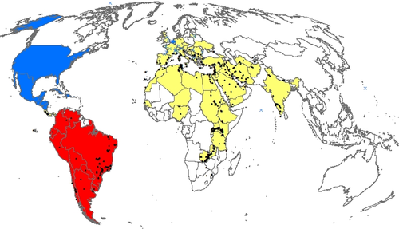

**Figure 1**

Open in figure viewer[PowerPoint](https://onlinelibrary.wiley.com/action/downloadFigures?id=ps6677-fig-0001&doi=10.1002%2Fps.6677)

Presence locations used to make models. See text for explanation of shading. Black points, known presences in the models; blue crosses, not used as they were records from glasshouse or inaccurate locations, or known to be far outside the area where *T. absoluta* can establish year-round outdoors populations. Shaded countries were used as background (see methods).

It is unusual to have verified data on locations where a species is absent. Therefore statistical SDMs often use ‘pseudo-absences’, where it is reasonable to believe the species is absent. To construct statistical SDMs and test the predictive accuracy of all approaches we sampled four sets of 340 pseudo-absences within the geographical background shaded in Fig. 1. This background corresponds to the native and long-term invaded range, and consisted of the following:

- South American countries in which *T. absoluta* is native and recorded (red). This restriction reduces the probability of drawing pseudo-absences from regions where the species is found, but has not been recorded. These are termed ‘false absences’, and would make it difficult for models to distinguish between suitable and unsuitable climate.
- Countries *T. absoluta* invaded during or before 2015 (yellow). Invasive species can take time to spread to all the areas climatically suitable for them (called reaching ‘equilibrium’<sup>46</sup>). In recently invaded countries *T. absoluta* may be absent from some areas because the species has not yet reached equilibrium, and drawing pseudo-absences from these regions would be ‘false absences’ (see above). We included Zambia in the invaded countries. Although *T. absoluta* did not reach Zambia until 2016, it has been sampled intensively and it is clear that *T. absoluta* has reached equilibrium there.<sup>47</sup> Countries invaded during/before 2015 includes countries in which *T. absoluta* occupies glasshouses, but does not have year-round populations outdoors (i.e. in Europe). If *T. absoluta* is not present outdoors year-round in these countries there is a strong chance this is a result of climatic unsuitability. By placing pseudo-absences in these countries we tested the hypothesis that Europe is climatically unsuitable (i.e. if SDMs find a clear difference between pseudo-absences in Europe and presences in the year-round range).
- Central America and the lower 48 US states (blue). These areas are geographically close to the native range and trade fruit and vegetables regularly with countries where *T. absoluta* is found. Thus it is highly likely that *T. absoluta* has had the opportunity to establish populations in this region, but has been prevented from doing so as a consequence of environmental unsuitability. Placing pseudo-absences in these countries tests the hypothesis that they are climatically unsuitable.

The geographical background did not include countries further from the species’ native and invaded range in order to prevent the modelling from contrasting completely different climate conditions (e.g. very cold *versus* warm). This very coarse contrast would only yield the information that *T. absoluta* can live in regions with a broadly tropical climate, and has been shown not to be informative.<sup>48-50</sup>

Following experimentation with several pseudo-absence placements, pseudo-absences were excluded from a 500 km buffer around the presence locations. When pseudo-absences were allowed to fall closer to observed presences models could not discriminate between suitable and unsuitable environments. This was likely because the pseudo-absences were false absences: thus, *T. absoluta* occupied some of the pseudo-absence locations, but was not recorded there. Excluding pseudo-absences from the buffer could somewhat reduce the precision of models in distinguishing suitable from unsuitable climate. This may affect the precision of the forecast of the edges of *T. absoluta'*s distribution, but not the accuracy with which the majority of the species’ range is projected. However, the improvement in accuracy of statistical SDMs when excluding pseudo-absences from a 500 km buffer demonstrated the benefit of this approach outweighed the downside.

### 2.3 Constructing statistical SDMs

We used 10 different SDM techniques: artificial neural networks (ANN), classification tree analysis (CTA), flexible discriminant analysis (FDA), generalised additive models (GAM), generalised boosted regression models (GBM), generalised linear models (GLM), multivariate adaptive regression splines (MARS), maximum entropy (MAXENT<sup>15</sup>), random forest (RF) and surface range envelope (SRE; note that this does not use pseudo-absence data to construct models). More details in Table S3. Analyses were undertaken in R<sup>51</sup> using the biomod2<sup>14</sup> and modEvA<sup>52</sup> packages, and default biomod2 settings.

### 2.4 Variable importance in statistical SDMs

The importance of environmental variables for *T. absoluta*'s range was calculated using all of the distribution data in a given dataset and using all models. For any given environmental variable, that variable was randomised, an SDM was made with the shuffled dataset and the Pearson's correlation (*r*) calculated between the SDMs with original and shuffled data. Importance is calculated as 1 – *r*, so a value 0 indicates the variable has no influence on the SDM. This was repeated for each SDM technique.

### 2.5 Constructing CLIMEX models

CLIMEX models have been constructed for *T. absoluta* by three peer-reviewed publications.<sup>23-25</sup> The later publications refined the earlier models. This high level of scrutiny suggested that it seemed unlikely we could improve on the most recently published model, and we therefore obtained the parameter values from the most recent publication<sup>25</sup> (Table S1). We used these parameters and the ‘Compare Locations (1 species)’ tool to project the Ecoclimatic Index (EI) for *T. absoluta*<sup>22</sup> across all terrestrial grid-cells. The EI is an overall measure of favourableness of the location for year-round occupation by the target species, on a scale of 0–100, where 100 is most favourable. Therefore, EI is analogous to the potential distributions projected by statistical SDMs. To compare directly to statistical SDMs, we converted the EI to a 0–1 numerical scale.

### 2.6 Semi-independent evaluation of statistical SDMs and CLIMEX

The AUC (Area Under the receiver operating Curve) measures the trade-off between sensitivity (predicting as suitable the places the species can live), and specificity (predicting as unsuitable the places where the species cannot live). An AUC value near 1 means the model can do both of these things simultaneously. Accuracy of the statistical SDMs was evaluated by the cross-validation AUC, splitting each of the presence and pseudo-absence datasets randomly so that 70% of the points were used to ‘calibrate’ the models. These models were used to predict the suitability at the 30% remaining ‘evaluation’ distribution data points, and the AUC calculated. Accuracy of the CLIMEX model was calculated as the AUC when the projection was compared against each of the four complete presence and pseudo-absence datasets in Distribution Data, above. We focus on AUC here, but other metrics employ sensitivity and specificity: Cohen's kappa and the True Skill Statistic (TSS).<sup>53</sup> Those metrics require a suitability threshold to be specified, and there is no single best way to determine the best threshold. Therefore, in this paper we focus on AUC, but the code we supply offers the option to use kappa or TSS, and additional options can be implemented. Because area predicted suitable often is used to evaluate CLIMEX, the ensemble.R code we provide calculates this for all projections.

### 2.7 Comparing results between environmental datasets, statistical SDMs and CLIMEX

In order to compare the statistical SDM results from each environmental dataset, we made a single, ensemble statistical SDM prediction for each variable set. It often is not advisable to obtain projections from a single statistical SDM technique that gives the highest AUC value, because the evaluation data may not be completely independent from the calibration data and this can inflate the AUC.<sup>9</sup> There is no statistical SDM technique that is *a priori* better than others, and the SDM techniques used have all been shown capable of producing highly accurate models whilst still making very different projections.<sup>54-56</sup> In these circumstances it is common to ensemble the results from several SDM techniques. This is based on the principle that the ‘signal’ emerges from the ‘noise’ associated with individual model errors and uncertainties,<sup>54, 57</sup> and ensembling can have superior predictive performance to individual models.<sup>58</sup> In order to produce an easily interpretable result we therefore created an ensemble projection for each combination of environmental variables.

In order to construct the ensemble, we selected statistical SDM techniques for which the cross-validation AUC >0.8.<sup>59</sup> Models with AUC >0.8 are considered to have ‘good’ performance (greater than ‘fair’, but less than ‘excellent’<sup>60</sup>). However, to construct the ensemble we constructed statistical SDMs using all presence and pseudo-absence points. This was to ensure that when a technique yielded good accuracy, all of the data then were included to maximise the information in the final model. We repeated this for each environmental dataset. The ensemble consensus prediction was the mean suitability projected by all selected statistical SDMs weighted by the mean predictive accuracy (AUC) of each model (methods described above; Fig. 2).

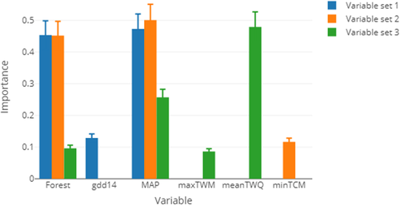

**Figure 2**

Open in figure viewer[PowerPoint](https://onlinelibrary.wiley.com/action/downloadFigures?id=ps6677-fig-0002&doi=10.1002%2Fps.6677)

Variable importance as calculated in statistical SDMs. Importance is calculated as 1 – *r*, where *r* is the Pearson's correlation calculated between the SDMs with original and shuffled data, so a value 0 indicates the variable has no influence on the SDM.

We mapped the disagreement between CLIMEX and the ensemble statistical SDM projections from each environmental dataset by subtracting the SDM projection from the EI (scaled from 0–1). In order to visually compare projections at range edges from statistical SDMs and CLIMEX we also used thresholds to convert the ensemble SDM maps of continuous suitability to maps of the areas where environment is suitable or unsuitable for *T. absoluta*. Projections from both approaches are commonly visualised in this way, yet it should be noted that using a threshold adds another level of uncertainty to results,<sup>61</sup> and can trick the viewer into thinking that the exact potential range margin can be projected more precisely than is really the case. Thresholds were calculated by comparing the continuous suitability map against presence and pseudo-absence data, and selecting suitability thresholds where a certain proportion of presence and pseudo-absence data were accurately projected to be suitable or unsuitable respectively. No single threshold can be said to be most accurate,<sup>62-64</sup> and we investigated four threshold approaches based on sensitivity (the proportion of presences projected to be in a suitable environment) and specificity (the proportion of pseudo-absences projected to be in an unsuitable environment). The thresholds were the suitability value that (i) fixed sensitivity at 95%, (ii) fixed sensitivity at 90%, (iii) maximised the sum of sensitivity and specificity, and (iv) minimised the difference between sensitivity and specificity. To calculate the thresholds, all 340 presences were used and 100 sets of 340 pseudo-absences were generated as described above. The thresholds were the averages of the values calculated for all of the 100 sets of pseudo-absences. Thresholds were applied to CLIMEX predictions using values of EI = 0 (unsuitable), 0 < EI < 30 (marginally suitable) and EI > 30 (highly suitable), following.<sup>25</sup>

### 2.8 Best projection of *T. absoluta* global, year-round distribution

We selected the environmental dataset for which statistical SDMs yielded the highest mean cross-validation AUC, the statistical SDMs for which cross-validation AUCs were >0.8, and constructed an ensemble of these models. We also included CLIMEX in the final consensus projection despite it receiving an AUC score <0.8. This is because parameters used in the CLIMEX model have been refined by three different sets of authors. Thus a broad range of experts are confident that the CLIMEX parameters used here represent the physiology of *T. absoluta*. As with statistical SDMs, the CLIMEX projection was weighted using the AUC score of the projected distribution. Uncertainty was calculated as the coefficient of variation between the individual models in the ensemble.

## 3 RESULTS

For SDMs made with gdd14 and with minTCM (variable sets 1 and 2; Table 2), some SDM techniques yielded good results (AUC > 0.8), whereas others were notably poor (AUC < 0.7). Evaluation statistics were far more encouraging for variable set 3, which includes meanTWQ (AUC > 0.8 for all SDM techniques). Additionally, the global projection map (Fig. S1) shows a clearer distinction between suitable and unsuitable conditions using variable set 3 than variable sets 1 and 2. meanTWQ appeared to have a strong effect on the results (Fig. 2). This evidence suggests that variable set 3 (maxTWM, MAP, Forest, meanTWQ) is the most accurate and informative.

Table 2. Summary statistics for all the models made, along with standard interpretations of the values in parentheses

| Model technique | Mean AUC (± SD) Model 1. minTCM, MAP, Forest | Mean AUC (± SD) Model 2. Gdd14, MAP, Forest | Mean AUC (± SD) Model 3. maxTWM, MAP, Forest, meanTWQ |
| --- | --- | --- | --- |
| GLM | 0.63 (±0.02) Poor | 0.59 (±0.06) Fail | 0.84 (±0.02) Good |
| GAM | 0.66 (±0.03) Poor | 0.66 (±0.05) Poor | 0.89 (±0.02) Good |
| SRE | 0.97 (±0.01) Excellent | 0.97 (±0.02) Excellent | 0.93 (±0.03) Excellent |
| RF | 0.71 (±0.02) Fair | 0.74 (±0.03) Fair | 0.91 (±0.02) Excellent |
| ANN | 0.59 (±0.09) Fail | 0.66 (±0.09) Poor | 0.83 (±0.04) Good |
| FDA | 0.64 (±0.03) Poor | 0.65 (±0.05) Poor | 0.9 (±0.02) Excellent |
| MAXENT.Phillips | 0.82 (±0.05) Good | 0.83 (±0.04) Good | 0.84 (±0.04) Good |
| CTA | 0.82 (±0.03) Good | 0.81 (±0.04) Good | 0.89 (±0.03) Good |
| GBM | 0.84 (±0.02) Good | 0.84 (±0.01) Good | 0.91 (±0.02) Excellent |
| MARS | 0.75 (±0.02) Fair | 0.74 (±0.02) Fair | 0.81 (±0.02) Good |
| CLIMEX | 0.74 (±0.01) Fair | 0.74 (±0.01) Fair | 0.75 (±0.01) Fair |

- Note that although the CLIMEX model tested was the same in all three columns, the mean AUC varies very slightly because different presence/pseudo-absence datasets were used.

CLIMEX gave a ‘fair’ AUC value of 0.74, which is fairly central within the range of values from the statistical SDM techniques and variable sets 1 and 2, but strikingly lower than those from variable set 3 (Table 2).

Statistical SDMs found that precipitation and temperature during the rainy season (MAP and meanTWQ) are key determinants of *T. absoluta*'s observed range (Fig. 2). Neither minTCM nor gdd14 were particularly important. Forest was particularly important within variable sets 1 and 2, and notably unimportant in variable set 3 (Table 2).

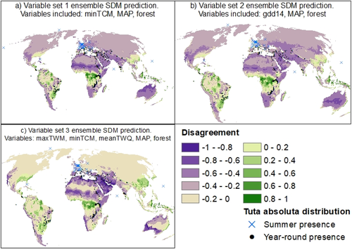

**Figure 3**

Open in figure viewer[PowerPoint](https://onlinelibrary.wiley.com/action/downloadFigures?id=ps6677-fig-0003&doi=10.1002%2Fps.6677)

Agreement between SDMs in the consensus projections (which include CLIMEX) and CLIMEX alone. CLIMEX's Ecoclimatic Index was divided by 100 to produce projections on the same numerical scale as the SDMs. Agreement was calculated by subtracting the SDM value from the CLIMEX values.

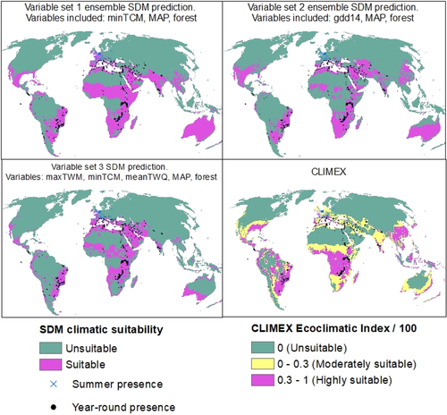

**Figure 4**

Open in figure viewer[PowerPoint](https://onlinelibrary.wiley.com/action/downloadFigures?id=ps6677-fig-0004&doi=10.1002%2Fps.6677)

Environmental suitability for *T. absoluta* projected using the consensus SDM projections as in Fig. 2, with suitable and unsuitable areas distinguished using the threshold that maximises the sum of sensitivity and specificity (Table 2). Thresholds were imposed on CLIMEX as used previously.<sup>25</sup>

The best, ensemble projection of the ultimate global distribution of year-round populations of *T. absoluta* was based on CLIMEX and statistical SDMs using variable set 3 (Fig. 5).

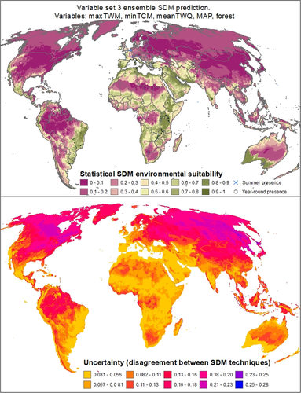

**Figure 5**

Open in figure viewer[PowerPoint](https://onlinelibrary.wiley.com/action/downloadFigures?id=ps6677-fig-0005&doi=10.1002%2Fps.6677)

Best projection of year-round suitability for *T. absoluta*, based on variable set 3 ensemble SDM including CLIMEX.

## 4 DISCUSSION

Neither minTCM nor gdd14 were particularly important in any variable set (Table 2), suggesting that *T. absoluta*'s observed distribution currently is not strongly limited by cold conditions. This also matches a CLIMEX model<sup>25</sup> that dropped the lower optimum temperature (DV1) from 20 °C in previous CLIMEX models to 14 °C based on the experimental findings.<sup>65</sup> Santana *et al*.<sup>25</sup> also dropped the cold temperature stress accumulation rate (THCS) by an order of magnitude compared to previous models, suggesting that cold periods only affect *T. absoluta* if they last longer than thought previously. Moreover, recent evidence has emerged that *T. absoluta* can enter facultative diapause, which is further evidence that cold temperatures do not limit its current range. However, the spread beyond the background region may well be limited by cold winters.

The strikingly different results from different environmental variable sets, both in projections and variable importance, underlines the importance of formally evaluating the fits of multiple models and datasets. A previous SDM using Maxent found the minimum temperature of the coldest month to be important.<sup>38</sup> However, the difference in results between variable sets, low importance of minTCM and gdd14, and previous findings<sup>25, 65</sup> suggest that low temperatures are not important limiters of *T. absoluta*'s current range. Here, Maxent performed better than some other techniques when using minTCM (Table 2), suggesting that the importance of this variable may possibly be related to technique, and that the previous Maxent predictions<sup>38</sup> may not be accurate.

Results from variable set 3 agreed more closely with CLIMEX than did results from variable set 1 or 2 (Fig. 3). The areas projected as suitable by CLIMEX and the consensus statistical SDM with variable set 3 largely coincide in South and Central America, southern Europe, and parts of Australia and East Africa (Figs 3, S1). The most concerning areas of disagreement are in southern Brazil and Uruguay, where six *T. absoluta* presence points fall into areas with disagreement ~0.3 and one ~0.4. CLIMEX predicts suitability to be notably higher than statistical SDMs in these areas [Fig. 3(c)]. This could suggest that statistical SDMs are measuring some environmental conditions as unsuitable for *T. absoluta* which the species can actually tolerate. However, this does not seem to lead to underprediction elsewhere; rather, projections from the statistical SDM ensemble with variable set 3 appeared to be more in line with *T. absoluta*'s distribution than those of CLIMEX. In particular, there are *T. absoluta* presence points elsewhere in the South American native range where statistical SDMs predicted substantially higher suitability than suitability found by CLIMEX (five points with disagreement ~ −0.3, four with disagreement ~ −0.4). Outside the native range *T. absoluta* is naturalised in areas where the ensemble statistical SDMs projected much higher suitability than CLIMEX: North Africa, the Arabian Peninsula and Central Asia [Fig. 3(c)]. This suggests that CLIMEX is underprojecting species’ potential distributions in these regions. Other areas where ensemble statistical SDMs projected higher suitability than CLIMEX are the western USA/Mexico, southern Australia and a strip of Africa below the Sahara. Given that previous CLIMEX models underpredicted the current distribution elsewhere, and that the data available when CLIMEX was parameterised were more limited than currently available (below), it seems likely that these regions are indeed suitable and that *T. absoluta* may eventually spread there.

CLIMEX projected much higher suitability than the statistical SDM ensemble with variable set 3 in areas from which *T. absoluta* is absent: much of Central Africa and parts of China, South America and Southeast Asia (Fig. 4). These areas are heavily forested (Fig. S2), a variable which could be included in statistical SDMs but not CLIMEX. These areas may be climatically suitable for *T. absoluta*, but not occupied owing to a lack of host plants, and unlikely to be widely invaded unless deforestation and cultivation of host plants is intensified. This emphasises the importance of including nonclimatic variables in distribution projections, particularly when large parts of species’ distributions are not governed by climate, for example for crop pests such as *T. absoluta* that do not tend to infest densely forested areas. Omitting important nonclimatic variables from any type of distribution model can lead to spurious relationships with climatic variables.<sup>6</sup> CLIMEX can include features such as forest or host crops in its Compare Locations via the biotic substrate functionality, if these features can be coded into the MetManager data file. However, the effect on pest population growth is user-defined, rather than calculated by the model, and only a single biotic substrate variable can be included. In addition, any interaction between environmental variables (e.g. climate and the presence or density of one or more crops infested by a pest) cannot be investigated. Statistical SDMs therefore have an advantage of being able to estimate the direct and interactive effects of any relevant, available environmental variable, including host plant data. An alternative to using ‘forest’ would be to use crop maps;<sup>66</sup> however, these are currently available only for the most widespread crop types, and thus not appropriate in this case.

CLIMEX projected much higher suitability than the consensus statistical SDM with variable set 3 in the southeast USA, which is unlikely to be caused by high forest cover. It may be that efforts to prevent the invasion of *T. absoluta*, for example by prohibiting import of tomato fruits and propagative materials from infested countries,<sup>67</sup> are working.

The CLIMEX model was validated<sup>25</sup> against fewer global *T. absoluta* presence records (148) than used in this report (340), and showed a high level of sensitivity (91% of records fell in areas where EI > 0). Visual comparison of Fig. 1 herein with fig. 1 in the previous smaller presence record validation<sup>25</sup> indicates that the distribution data that we used included almost all of the records used previously but additionally included points from the Arabian Peninsula, Central Asia and India. In the former two regions the most recent CLIMEX model appeared to underproject suitability for *T. absoluta*. This suggests that CLIMEX modelling may improve if it was repeated with the more recent data. This also illustrates that despite drawing on independent ecophysiological data, CLIMEX is not immune to the problems of parameterising range models with historic invasion data, before a species reaches equilibrium.<sup>46</sup> CLIMEX attempts to avoid this problem by using ‘prevalence’ (size of area predicted suitable) rather than specificity in numerical evaluation of model fit (i.e. CXIC). However, our result shows that disequilibrium can cause CLIMEX to underpredict the potential range, just as it would for statistical SDMs.

In order to minimise the risk that disequilibrium could lead statistical SDMs to underpredict the potential range, we excluded pseudo-absences from a 500 km buffer around presence locations. This appears to have been somewhat successful, because the best statistical SDM (variable set 3) did not predict substantially lower suitability than CLIMEX in almost areas where *T. absoluta* is currently found. However, disequilibrium means we cannot rule out that the statistical SDM underpredicted the species’ potential range. As *T. absoluta* continues to spread it may reveal even broader environmental tolerances than we currently measure. An added challenge for any modelling approach is that environmental tolerances may change rapidly following invasion.<sup>9</sup> It recently has been suggested that this may be the case for *T. absoluta*.<sup>68</sup>

In conclusion, we suggest that CLIMEX should be considered as one of a suite of SDM techniques, and the results from it and other models compared formally (i.e. numerically), interpreted clearly and ensembled if appropriate. The limitations of information that can be drawn from the species’ current distribution must be considered when doing this (i.e. environmental disequilibrium). In this regard it can be informative to compare results based entirely on species’ distributions (i.e. statistical SDMs) to results from sensible, experimentally informed values of key ecophysiological parameters (e.g. CLIMEX, or less formally using expert knowledge on species’ ecology). However, although CLIMEX draws on independent assessments of ecophysiology, the underpredictions that we found indicate it is not immune to the problems of disequilibrium, which are inherent when dealing with an emerging crop pest. Disagreement between modelling approaches and datasets may inform where available distribution or environmental data do not fully represent a species’ environmental tolerances. Therefore, if species’ range projections are to be used for management purposes, multiple modelling techniques should be used, numerically evaluated against independent or semi-independent data on the species’ known distribution, and the uncertainty and any potential causes interpreted for end-users. We provide tools to do this. Nonclimatic environmental variables with a potentially strong range limiting effect for the species of interest should be included in models, and the distributions of forest or particular crops may be particularly important for crop pests.

## ACKNOWLEDGEMENTS

We are grateful to Margaret Bolton for obtaining distribution data on *T. absoluta*, to Paulo Antonio Santana for discussing the parameterisation of the CLIMEX model with us, and to two anonymous reviewers for their advice. Funding was provided by BBSRC GCRF IAA sub-award SW-07640. This study was conducted as part of the Action on Invasives (AoI) programme funded by the United Kingdom (Foreign, Commonwealth & Development Office) and Netherlands (Directorate-General for International Cooperation). CABI is an international intergovernmental organisation and we gratefully acknowledge the core financial support from our member countries (and lead agencies) including the United Kingdom (Foreign, Commonwealth & Development Office), China (Chinese Ministry of Agriculture and Rural Affairs), Australia (Australian Centre for International Agricultural Research), Canada (Agriculture and Agri-Food Canada), Netherlands (Directorate-General for International Cooperation-DGIS), Switzerland (Swiss Agency for Development and Cooperation) and Ireland (Irish Aid, International Fund for Agricultural Development-IFAD). See [https://www.cabi.org/about-cabi/who-we-work-with/key-donors/](https://www.cabi.org/about%E2%80%90cabi/who%E2%80%90we%E2%80%90work%E2%80%90with/key%E2%80%90donors/) for details.

## CONFLICT OF INTEREST

None to declare.

## AUTHOR CONTRIBUTIONS

RE conceived the paper, conducted modelling, and drafted the manuscript; RD contributed to methodological decisions, ecological information, the interpretation of results, and commented on the manuscript; and IR and GC contributed substantial data.

## AVAILABILITY OF DATA AND MATERIAL

Georeferenced distribution data extracted from the literature and utilised (before filtering to one presence per grid-cell) are in Table S3.

## CODE AVAILABILITY

Code and a reproducible example for assessing confidence in CLIMEX projections and integrating with projections from statistical SDMs, are in the GitHub repository https://github.com/Fabiogeography/biomod_climex

## REFERENCES

[figure not shown]

[Volume78, Issue2](https://onlinelibrary.wiley.com/toc/15264998/2022/78/2)

February 2022

Pages 671-683

### Recommended

  [H. KEHLENBECK](https://onlinelibrary.wiley.com/action/doSearch?ContribAuthorRaw=KEHLENBECK%2C+H),

  [Methods in Ecology and Evolution](https://besjournals.onlinelibrary.wiley.com/journal/2041210x)
- [Assessing the accuracy of species distribution models: prevalence, kappa and the true skill statistic (TSS)](https://besjournals.onlinelibrary.wiley.com/doi/full/10.1111/j.1365-2664.2006.01214.x)

  [Journal of Applied Ecology](https://besjournals.onlinelibrary.wiley.com/journal/13652664)

[Download PDF](https://onlinelibrary.wiley.com/doi/pdf/10.1002/ps.6677)

[figure not shown]

0

3

0